# We’re making a blog (IDE agnostic edition)

quarto

Making a Quarto blog and deploying it on GitHub Pages, step by step.

Published

September 4, 2023

My partner, Val, has been asking to making a fancy Quarto blog. Today, we’re going through this step-by-step together. There’s a few different ways to do this, and the RStudio IDE has UI to make this a pretty slick process. However, I don’t spend much time in RStudio, so here’s my IDE agnostic workflow. You’ll need:

- A GitHub account
- To [install Quarto here if you haven’t yet](https://quarto.org/docs/get-started/)
- Access to the command line (eg, “Terminal” on a Mac)

### Step 1: Make the repository

Go to github.com and click on your profile image in the top right corner. In the dropdown, click on `Your repositories` and then click `New` to create a new repository.

[figure not shown]

Create a new repository in GitHub and name it `your-github-username.github.io`. This is a secret repository structure in GitHub to host a blog for your account! Next, open up the terminal and use the `cd` command to navigate to the folder you would like to store your blog in. Use the command `git clone {repository-url}` to copy the repository onto your computer, and `cd your-github-username.github.io` into your local version.

### Step 2: Create blog

In the folder for your repository, type `quarto create project blog .` into your CLI tool and press enter. Congratulations, you have built a blog! Use `quarto preview` to build and view it locally.

### Step 3: Update the blog

There’s a few places you will want to update before you publish your blog for the world to see. First, open up the file called `index.qmd` and add some information about yourself. I have a few sentences of introduction, my education, and how to get in contact with me. Next, open up the folder called `posts/` and update it to remove the default posts. If you’d like to write a blog post of your own, the easiest way to organize the posts is by making each one into its own folder. Then, each folder can contain a `.qmd`, `.md`, `.Rmd`, or `.ipynb` file as a post and any relevant images.

For simple aesthetics, you can go to the `_quarto.yml` file and [try out different bootstrap themes](https://quarto.org/docs/websites/website-blog.html#themes), or add some color to your navbar by adding a `background` field to your navbar

```yaml
website:
  title: "my blog"
  description: "my personal blog"
  navbar:
    background: "#ffccff" # accepts color names like red, blue, or hex codes
```

### Step 4: Push to Github Pages

While still in the folder of your blog, run `quarto publish gh-pages`. You will be prompted with some text like: Publish site to your-github-username.github.io? Accept this, and let it run.

### Step 5: Set the deployment branch to `gh-pages`

Back to GitHub, view your repository. Go to the settings for the repo, and click on `Pages`. Then, change the `Build and deploy from source` to the `gh-pages` branch.

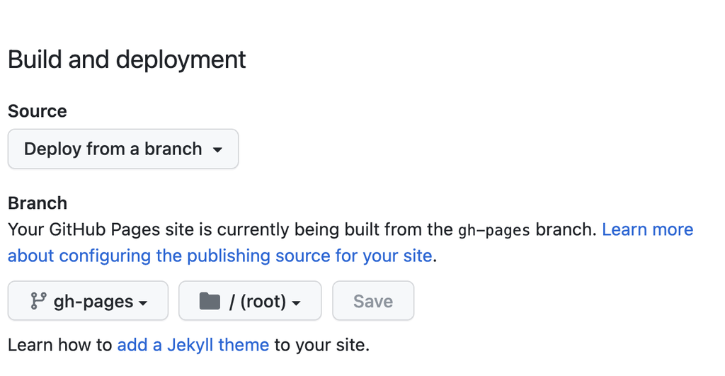

If you go back to the main page of your repository, you will see a tab `Deployments` underneath the repository description. The green checkmark means your blog has been successfully deployed! The url will be something like `your-github-username.github.io`

Going forward, each time you want to update your website, you can reuse the `quarto publish gh-pages` command.